# Análisis Exploratorio de Datos (EDA): Morfometría de Dyme ramulus

Víctor Bustos - Proyecto Fásmidos 2026

2026-08-07

## 0. Limpieza de datos crudos

La inspección inicial del conjunto de datos reveló inconsistencias lógicas entre las características registradas (`estado`, `eclosion`, `vivos`). Ciertos especímenes presentaban una clasificación biológica que contradecía su estado vital absoluto. Para garantizar la validez de la inferencia, se aplicó una regla de limpieza antes del análisis.

Las modificaciones estructurales incluyen:

- **Estandarización nominal:** `Eclosion` $\rightarrow$ `Eclosionó`; `No viable` $\rightarrow$ `No eclosionó`.
- **Reclasificación lógica:** Corrección de los falsos positivos/negativos, ajustando el conteo de la cohorte viable a 18 Adultos y 35 Eclosionados.

```r
# Carga de datos originales para auditoría
df_raw <- readxl::read_excel("../data/raw/p_EGGS_EJES.xlsx", sheet = "DATA_MOD_01")

# Identificación de características en conflicto
df_raw |>
  group_by(estado, eclosion, vivos) |>
  summarise(n = n(), porcentaje = round((n / nrow(df_raw)) * 100, 2), .groups = 'drop')
```

```
## # A tibble: 5 × 5
##   estado    eclosion vivos     n porcentaje
##   <chr>     <chr>    <chr> <int>      <dbl>
## 1 Adulto    SI       NO        2       0.59
## 2 Adulto    SI       SI       17       5.03
## 3 Eclosion  SI       NO       33       9.76
## 4 Eclosion  SI       SI        1       0.3
## 5 No viable NO       NO      285      84.3
```

```r
# Línea base de la variable objetivo
df_raw |>
  group_by(estado) |>
  summarise(n = n(), porcentaje = round((n / nrow(df_raw)) * 100, 2))
```

```
## # A tibble: 3 × 3
##   estado        n porcentaje
##   <chr>     <int>      <dbl>
## 1 Adulto       19       5.62
## 2 Eclosion     34      10.1
## 3 No viable   285      84.3
```

## 1. Ingesta de Datos Procesados

Se emplea el archivo `.rds` derivado del script de limpieza para asegurar la preservación de los metadatos y factores categóricos ordenados, estableciendo la base inmutable para el EDA.

```r
df <- readRDS("../data/processed/fasmidos_clean.rds")
glimpse(df)
```

```
## Rows: 338
## Columns: 9
## $ cantidad <dbl> 1, 2, 3, 4, 5, 6, 7, 8, 9, 10, 11, 12, 13, 14, 15, 16, 17, 18…
## $ parejas  <chr> "A", "A", "A", "A", "A", "A", "A", "A", "A", "A", "A", "A", "…
## $ puesta   <chr> "OR01", "OR01", "OR01", "OR01", "OR01", "OR01", "OR01", "OR01…
## $ estado   <fct> Eclosionó, Adulto, No eclosionó, No eclosionó, Eclosionó, Ecl…
## $ altura   <dbl> 1.97, 2.07, 2.02, 2.02, 2.13, 2.00, 1.95, 2.01, 1.93, 2.01, 1…
## $ longitud <dbl> 2.31, 2.40, 2.35, 2.28, 2.25, 2.22, 2.14, 2.18, 2.17, 2.18, 2…
## $ ancho    <dbl> 1.58, 1.68, 1.65, 1.62, 1.63, 1.62, 1.54, 1.47, 1.48, 1.64, 1…
## $ eclosion <chr> "SI", "SI", "NO", "NO", "SI", "SI", "NO", "NO", "NO", "SI", "…
## $ vivos    <chr> "NO", "SI", "NO", "NO", "NO", "NO", "NO", "NO", "NO", "NO", "…
```

## 2. Validación Estructural

Auditoría de valores atípicos extremos (NAs) y distribución de frecuencias. Identificar tempranamente el desbalance severo de clases (aproximadamente 84% fallos frente a 16% éxitos) es el fundamento metodológico que justificará el uso de pruebas de hipótesis no paramétricas en fases posteriores.

```r
summary(df)
```

```
##     cantidad        parejas             puesta                   estado
##  Min.   :  1.00   Length:338         Length:338         No eclosionó:285
##  1st Qu.: 85.25   Class :character   Class :character   Eclosionó   : 35
##  Median :169.50   Mode  :character   Mode  :character   Adulto      : 18
##  Mean   :169.50
##  3rd Qu.:253.75
##  Max.   :338.00
##      altura         longitud         ancho         eclosion
##  Min.   :1.450   Min.   :1.960   Min.   :1.150   Length:338
##  1st Qu.:1.853   1st Qu.:2.100   1st Qu.:1.480   Class :character
##  Median :1.910   Median :2.160   Median :1.530   Mode  :character
##  Mean   :1.912   Mean   :2.168   Mean   :1.527
##  3rd Qu.:1.990   3rd Qu.:2.250   3rd Qu.:1.580
##  Max.   :2.130   Max.   :2.450   Max.   :1.810
##     vivos
##  Length:338
##  Class :character
##  Mode  :character
##
##
##
```

```r
df |>
  group_by(estado) |>
  summarise(n = n(), porcentaje = round((n / nrow(df)) * 100, 2))
```

```
## # A tibble: 3 × 3
##   estado           n porcentaje
##   <fct>        <int>      <dbl>
## 1 No eclosionó   285      84.3
## 2 Eclosionó       35      10.4
## 3 Adulto          18       5.33
```

## 3. Dispersión Univariada

Evaluación del comportamiento asimétrico de los ejes físicos. El propósito es identificar visualmente límites de viabilidad inferiores (“hard boundaries”) o distribuciones multimodales que puedan sugerir dimorfismo estructural en los especímenes.

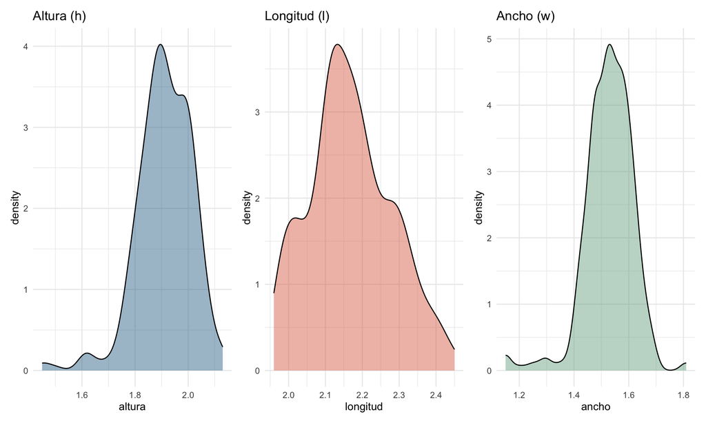

```r
p_alt <- ggplot(df, aes(x = altura)) +
  geom_density(fill = "#457b9d", alpha = 0.5) + theme_minimal() + labs(title = "Altura (h)")

p_lon <- ggplot(df, aes(x = longitud)) +
  geom_density(fill = "#e07a5f", alpha = 0.5) + theme_minimal() + labs(title = "Longitud (l)")

p_anc <- ggplot(df, aes(x = ancho)) +
  geom_density(fill = "#81b29a", alpha = 0.5) + theme_minimal() + labs(title = "Ancho (w)")

(p_alt | p_lon | p_anc)
```

## 4. Dispersión Condicionada (Poder Discriminante)

Contraste de la varianza morfológica estratificada por estado biológico. Este enfoque busca localizar de forma preliminar qué dimensión física presenta la mayor separación intercuartílica, señalando las variables candidatas a explicar la supervivencia embrionaria.

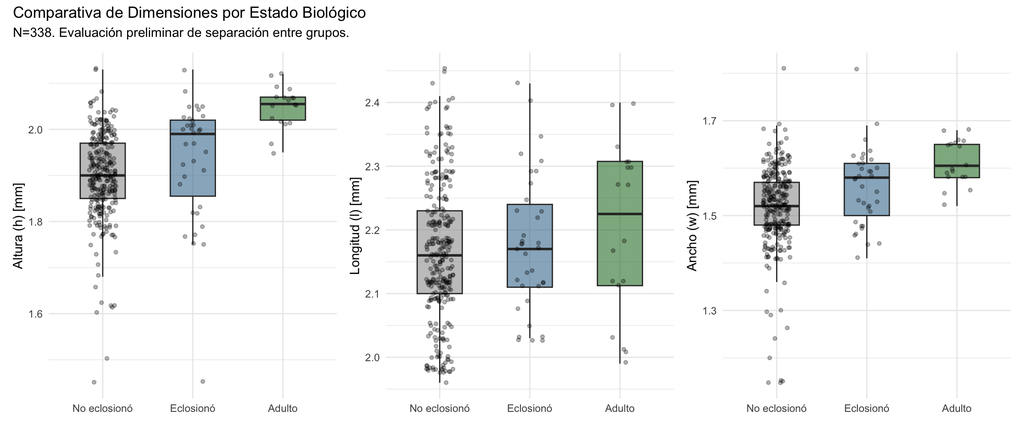

```r
plot_biometria <- function(var, label_y) {
  ggplot(df, aes(x = estado, y = .data[[var]], fill = estado)) +
    geom_boxplot(alpha = 0.6, outlier.shape = NA, width = 0.5) +
    geom_jitter(width = 0.15, alpha = 0.3, size = 1.2) +
    scale_fill_manual(values = c("No eclosionó" = "#9E9E9E", "Eclosionó" = "#457b9d", "Adulto" = "#2E7D32")) +
    theme_minimal() +
    theme(legend.position = "none", axis.title.x = element_blank()) +
    labs(y = label_y)
}

p_alt_box <- plot_biometria("altura", "Altura (h) [mm]")
p_lon_box <- plot_biometria("longitud", "Longitud (l) [mm]")
p_anc_box <- plot_biometria("ancho", "Ancho (w) [mm]")

(p_alt_box | p_lon_box | p_anc_box) +
  plot_annotation(title = "Comparativa de Dimensiones por Estado Biológico",
                  subtitle = "N=338. Evaluación preliminar de separación entre grupos.")
```

## 5. Matriz de Correlación y Sincronía de Crecimiento

El análisis de colinealidad es fundamental para la construcción de modelos estadísticos robustos. Se busca comprobar si las dimensiones transversal y longitudinal crecen de forma proporcional (redundancia de la información) o si operan como vectores independientes, lo cual afectaría la varianza explicada en una regresión logística.

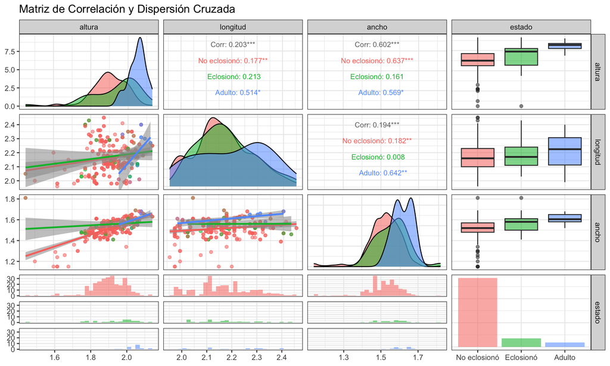

```r
library(GGally)

df |>
  select(altura, longitud, ancho, estado) |>
  ggpairs(aes(color = estado, alpha = 0.5),
          upper = list(continuous = wrap("cor", size = 3)),
          lower = list(continuous = "smooth")) +
  theme_bw() +
  labs(title = "Matriz de Correlación y Dispersión Cruzada")
```

## 6. Resolución de Umbrales (Ridge Plots)

Mientras los gráficos de caja ocultan la densidad subyacente, los perfiles de crestas evidencian el solapamiento estocástico de las poblaciones. El objetivo analítico aquí es detectar la existencia de umbrales biomecánicos (“puntos de corte” visuales), por debajo de los cuales la viabilidad eclosional decae a cero.

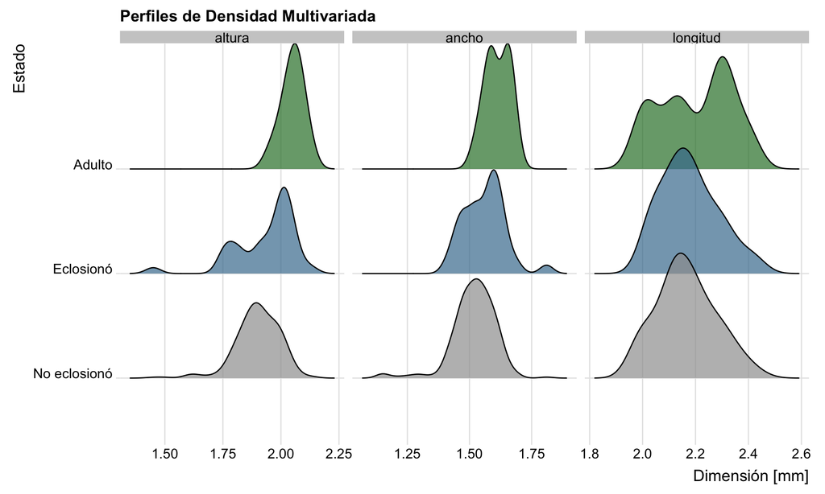

```r
library(ggridges)

df_long <- df |>
  pivot_longer(cols = c(altura, longitud, ancho),
               names_to = "dimension",
               values_to = "medida")

ggplot(df_long, aes(x = medida, y = estado, fill = estado)) +
  geom_density_ridges(alpha = 0.7, scale = 1.2) +
  facet_wrap(~dimension, scales = "free_x") +
  scale_fill_manual(values = c("No eclosionó" = "#9E9E9E", "Eclosionó" = "#457b9d", "Adulto" = "#2E7D32")) +
  theme_ridges() +
  theme(legend.position = "none") +
  labs(title = "Perfiles de Densidad Multivariada",
       x = "Dimensión [mm]", y = "Estado")
```